# week_7_excercises_data

J.Blondeau

2024-10-03

This week is all about making plots and graphs in ggplot2. The only datasets you need are in the /data directory.

1. sttstj_fish_biomass
2. taxonomic

```r
library(readr)
library(tidyverse)
```

```r
library(ggplot2)
library(dplyr)

fish_bio<- read_csv("data/sttstj_fish_biomass.csv")
tax<-read_csv("data/taxonomic.csv")
```

In this instance, anytime you need to group by and summarize, you can just take the mean of biomass and SE. This would not always be appropriate, but for this case the exercises are for plotting and graphing.

**put all your code in the .Rmd file inside a code chunk for each question. Annotate what you are doing so that you can reference them later.

1. Create a line graph of biomass over time for Red hind (“EPI GUTT”) inside the national park.

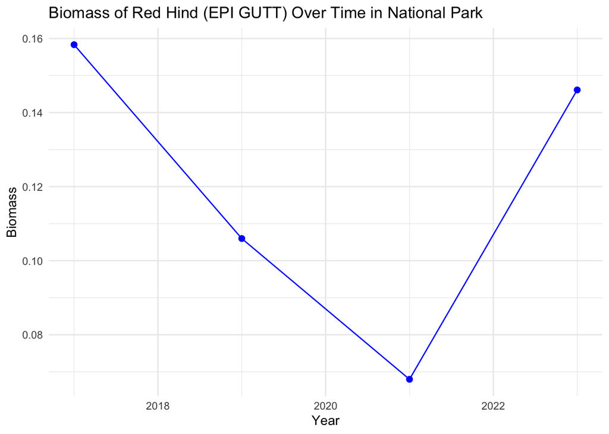

```r
# Filter the data for Red Hind (EPI GUTT) inside the national park (protected_status == 1)
red_hind <- fish_bio %>%
  filter(SPECIES_CD == "EPI GUTT", protected_status == 1)



# Create a line plot of biomass over time (YEAR)
ggplot(red_hind, aes(x = YEAR, y = biomass)) +
  geom_line(color = "blue") +  # Line for biomass over time
  geom_point(size = 2, color = "blue") +  # Add points for each year
  labs(title = "Biomass of Red Hind (EPI GUTT) Over Time in National Park",
       x = "Year",
       y = "Biomass") +
  theme_minimal()
```

2. Create a point and line graph of biomass over time for Yellowtail Snapper (“OCY CHRY”) outside the national park.

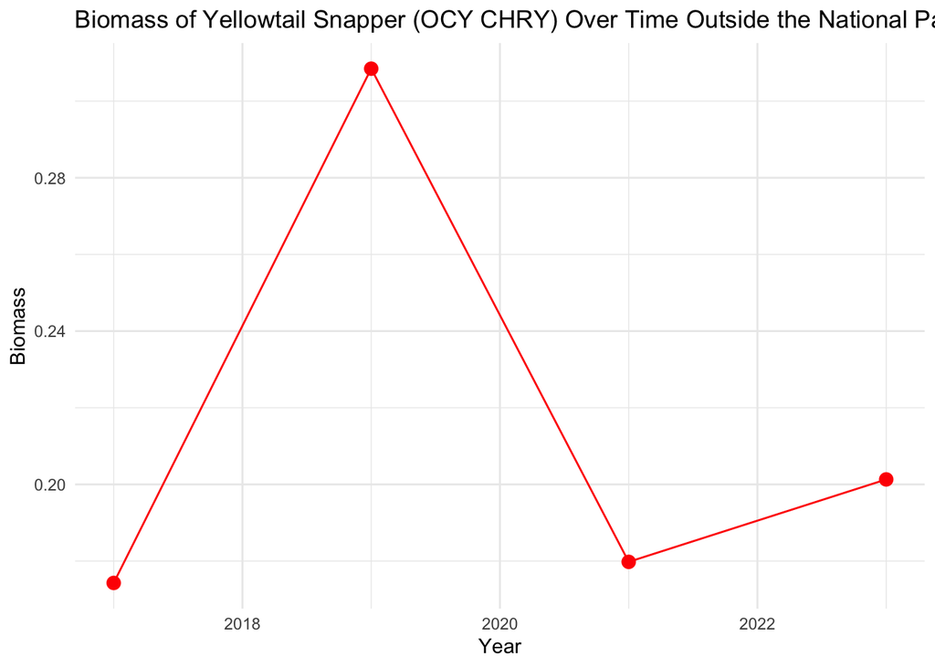

```r
# Filter the data for Yellowtail Snapper (OCY CHRY) outside the national park (protected_status == 0)
yellowtail <- fish_bio %>%
  filter(SPECIES_CD == "OCY CHRY", protected_status== 0)


# Create a point and line plot of biomass over time (YEAR)
ggplot(yellowtail, aes(x = YEAR, y = biomass)) +
  geom_line(color = "red") +  # Line for biomass over time
  geom_point(size = 3, color = "red") +  # Points for each year
  labs(title = "Biomass of Yellowtail Snapper (OCY CHRY) Over Time Outside the National Park",
       x = "Year",
       y = "Biomass") +
  theme_minimal()
```

3. Create a bar graph of biomass over time for each species grouped by protected_status. Edit the the axis and legend titles to be more insightful.
   - biomass units
   - Scientific name instead of SPECIES_CD
   - 0 = Open, 1 = VI National Park

```r
# Convert protected_status to a factor with meaningful labels
fish_bio <- fish_bio %>%
  mutate(protected_status = factor(protected_status,
                                   levels = c(0, 1),
                                   labels = c("Open", "VI National Park")))


# Summarize biomass for each species and year
parrotfish <- fish_bio %>%
  filter(trophic=="parrotfish")%>%
  group_by(YEAR, protected_status) %>%
  summarise(total_biomass = sum(biomass))
```

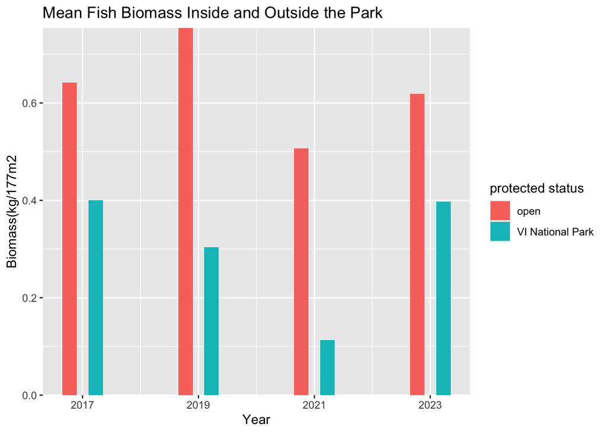

```r
ggplot(data=parrotfish, aes(x=YEAR, y=total_biomass, fill=factor(protected_status)))+
  geom_bar(stat= "identity", position= position_dodge(0.9), width=0.5)+
  labs(title= "Mean Fish Biomass Inside and Outside the Park",
       x="Year",
       y="Biomass(kg/177m2",
       fill="protected status")+
  scale_fill_manual(values=c("0"="red", "1"="blue"),
                    name=element_blank(),
                    labels=c("outside", "Inside"))+
  scale_x_continuous(breaks=c(2017,2019,2021,2023))+
  scale_y_continuous(expand=c(0,0))+
  scale_fill_discrete(labels=c("open", "VI National Park"))
```

4. Create a bar graph of trophic-level mean biomass inside and outside VI national park for each species.

```r
trophic_summary <- fish_bio %>%
  group_by(YEAR, trophic, protected_status) %>%
  summarise(sum_biomass = sum(biomass, na.rm = TRUE))%>%
  ungroup()%>%
  group_by(trophic, protected_status)%>%
  summarise(mean_biomass=mean(sum_biomass))
```

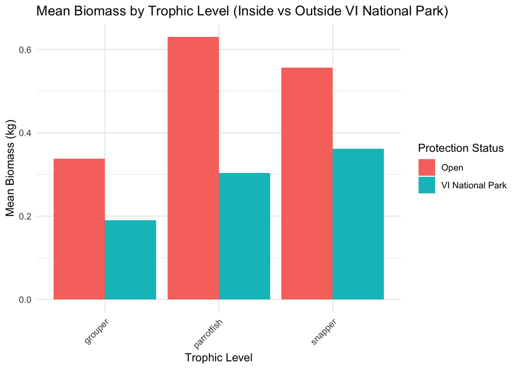

```r
# Create the bar plot
ggplot(trophic_summary, aes(x = trophic, y = mean_biomass, fill = protected_status)) +
  geom_bar(stat = "identity", position = "dodge") +  # Dodged bars for inside/outside the park
  labs(title = "Mean Biomass by Trophic Level (Inside vs Outside VI National Park)",
       x = "Trophic Level",
       y = "Mean Biomass (kg)",  # Adjust units if necessary
       fill = "Protection Status") +  # Legend title for protection status
  theme_minimal() +
  theme(axis.text.x = element_text(angle = 45, hjust = 1))
```

5. Create a point and line plot of ‘grouper’ biomass (+- SE) over time; inside and outside park together.

```r
# Filter the data for groupers only
grouper_data <- fish_bio %>%
  filter(trophic == "grouper")

# Summarize biomass and SE by year and protection status
grouper_summary <- grouper_data %>%
  group_by(YEAR, protected_status) %>%
  summarise(mean_biomass = mean(biomass, na.rm = TRUE),
            se_biomass = mean(SE, na.rm = TRUE))
```

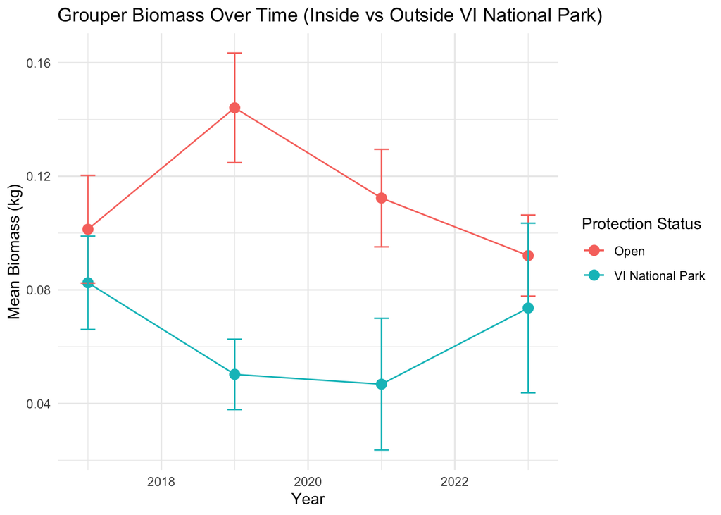

```r
ggplot(grouper_summary, aes(x = YEAR, y = mean_biomass, color = protected_status)) +
  geom_line() +  # Line plot for biomass over time
  geom_point(size = 3) +  # Points for each year
  geom_errorbar(aes(ymin = mean_biomass - se_biomass, ymax = mean_biomass + se_biomass), width = 0.2) +  # Error bars for SE
  labs(title = "Grouper Biomass Over Time (Inside vs Outside VI National Park)",
       x = "Year",
       y = "Mean Biomass (kg)",
       color = "Protection Status") +  # Update legend title
  theme_minimal()
```